# Sample Size Calculation Example

Zehui Bai

2024-12-02 12:06:42

# 1 Introduction

To install and load `pwrss`:

```
install.packages("pwrss")
library(pwrss)
```

`pwrss` R package allows statistical power and minimum required sample size calculations for

- `(1)` testing a proportion (one-sample) against a constant,
- `(2)` testing a mean (one-sample) against a constant,
- `(3)` testing difference between two proportions (independent samples),
- `(4)` testing difference between two means (independent and paired samples),
- `(5)` testing a correlation (one-sample) against a constant,
- `(6)` testing difference between two correlations (independent samples),
- `(7)` testing a coefficient (standardized or unstandardized) against a constant in multiple linear regression,
- `(8)` testing an indirect effect (standardized or unstandardized) in the mediation analysis (Sobel, Joint, and Monte Carlo),
- `(9)` testing an R-squared against zero in linear regression
- `(10)` testing an R-squared difference against zero in hierarchical regression
- `(11)` testing an eta-squared or f-squared (for main and interaction effects) against zero in analysis of variance (ANOVA) (could be one-way, two-way, and three-way),
- `(12)` testing an eta-squared or f-squared (for main and interaction effects) against zero in analysis of covariance (ANCOVA) (could be one-way, two-way, and three-way),
- `(13)` testing an eta-squared or f-squared (for between, within, and interaction effects) against zero in one-way repeated measures analysis of variance (RM-ANOVA) (with non-sphericity correction and repeated measures correlation).

Alternative hypothesis can be formulated as “not equal”, “less”, “greater”, “non-inferior”, “superior”, or “equivalent” in `(1)`, `(2)`, `(3)`, and `(4)`; as “not equal”, “less”, or “greater” in `(5)`, `(6)`, `(7)` and `(8)`; but always as “greater” in `(9)`, `(10)`, `(11)`, `(12)`, and `(13)`. **If you find the package and related material useful, along with other references, please cite as:**

- Bulus, M. (2022). pwrss: Power and Sample Size Calculation Tools. R package version 0.1.0. https://CRAN.R-project.org/package=pwrss
- Bulus, M., & Polat, C. (2022, November 7). Istatistiksel Guc Analizine Giris [Introduction to Statistical Power Analysis]. https://doi.org/10.35542/osf.io/tfyxq

# 2 Generic Functions for *z*, *t*, and *F* tests

These generic functions calculate and return statistical power along with optional plots for Type I and Type II error rates (as long as the test statistic and degrees of freedom is known).

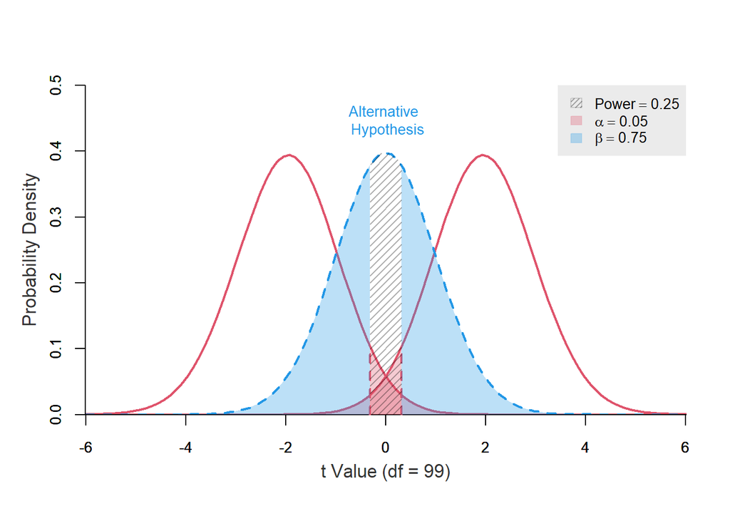

```r
power.t.test(ncp = 1.96, df = 99, alpha = 0.05,
             alternative = "equivalent", plot = TRUE)
```

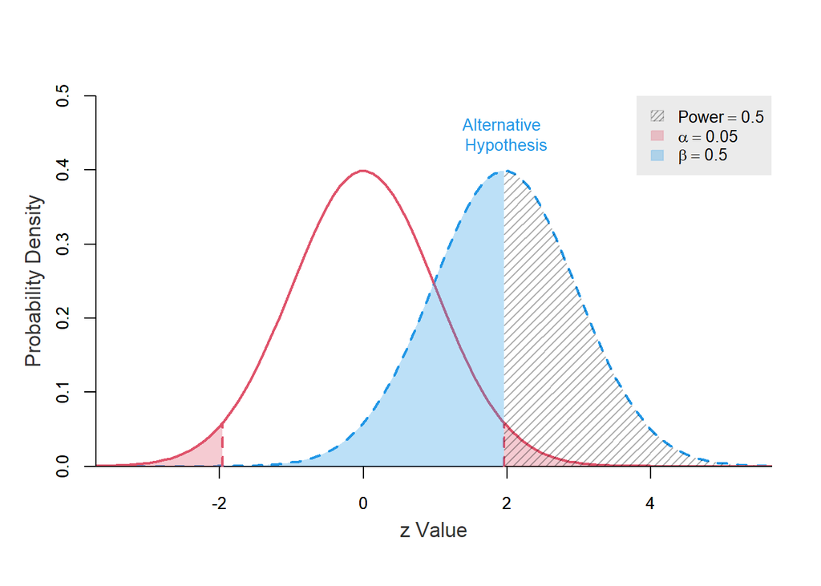

```r
power.z.test(ncp = 1.96, alpha = 0.05,
             alternative = "not equal", plot = TRUE)
```

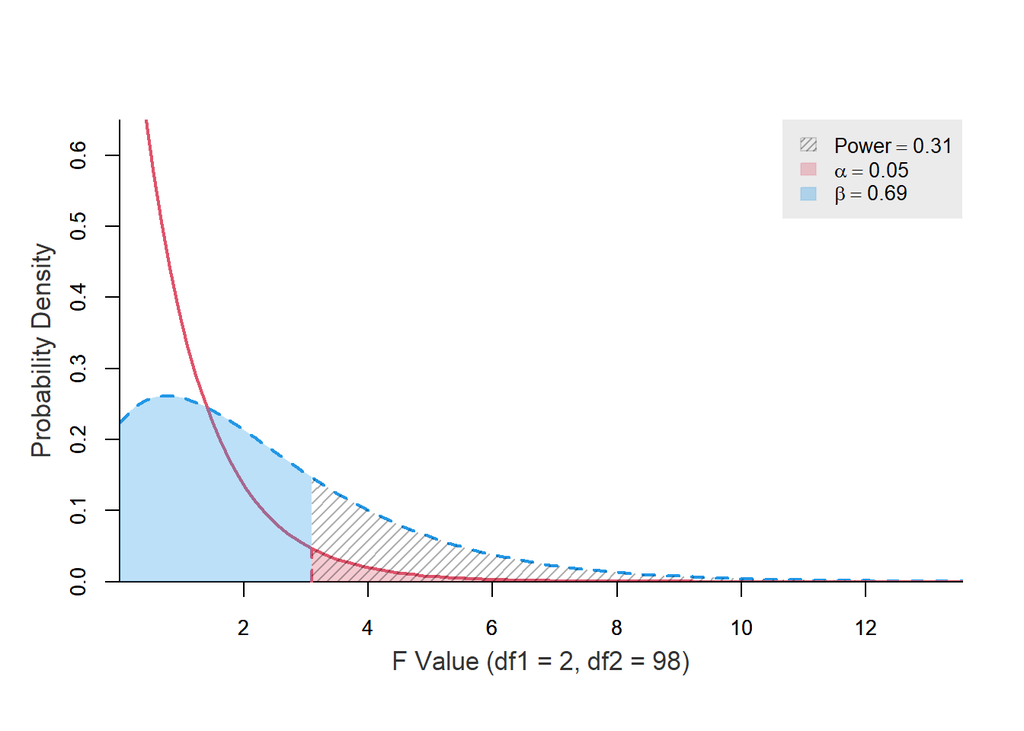

```r
power.f.test(ncp = 3, df1 = 2, df2 = 98,
             alpha = 0.05, plot = TRUE)
```

# 3 Practice

## 3.1 One Proportion

```r
# normal approximation
pwrss.z.prop(p = 0.45, p0 = 0.50,
                         alpha = 0.05, power = 0.80,
                         alternative = "less",
                         arcsin.trans = FALSE)%>% plot()
```

```
##  Approach: Normal Approximation
##  A Proportion against a Constant (z Test)
##  H0: p = p0
##  HA: p < p0
##  ------------------------------
##   Statistical power = 0.8
##   n = 613
##  ------------------------------
##  Alternative = "less"
##  Non-centrality parameter = -2.486
##  Type I error rate = 0.05
##  Type II error rate = 0.2
```

```r
# arcsine transformation
pwrss.z.prop(p = 0.45, p0 = 0.50,
             alpha = 0.05, power = 0.80,
             alternative = "less",
             arcsin.trans = TRUE)%>% plot()
```

```
##  Approach: Arcsine Transformation
##  A Proportion against a Constant (z Test)
##  H0: p = p0
##  HA: p < p0
##  ------------------------------
##   Statistical power = 0.8
##   n = 617
##  ------------------------------
##  Alternative = "less"
##  Non-centrality parameter = -2.486
##  Type I error rate = 0.05
##  Type II error rate = 0.2
```

```r
## Non-inferiority Test
pwrss.z.prop(p = 0.45, p0 = 0.50, margin = 0.01,
             alpha = 0.05, power = 0.80,
             alternative = "non-inferior")%>% plot()
```

```
##  Approach: Normal Approximation
##  A Proportion against a Constant (z Test)
##  H0: p - p0 <= margin
##  HA: p - p0 > margin
##  ------------------------------
##   Statistical power = 0.8
##   n = 426
##  ------------------------------
##  Alternative = "non-inferior"
##  Non-centrality parameter = -2.486
##  Type I error rate = 0.05
##  Type II error rate = 0.2
```

## 3.2 Difference between Two Proportions (Independent)

```r
# one side normal approximation

pwrss.z.2props(p1 = 0.45, p2 = 0.50,
               alpha = 0.05, power = 0.80,
               alternative = "less",
               arcsin.trans = FALSE)%>% plot()
```

```
##  Approach: Normal Approximation
##  Difference between Two Proportions
##  (Independent Samples z Test)
##  H0: p1 = p2
##  HA: p1 < p2
##  ------------------------------
##   Statistical power = 0.8
##   n1 = 1231
##   n2 = 1231
##  ------------------------------
##  Alternative = "less"
##  Non-centrality parameter = -2.486
##  Type I error rate = 0.05
##  Type II error rate = 0.2
```

```r
## Non-inferiority Test
pwrss.z.2props(p1 = 0.45, p2 = 0.50, margin = 0.01,
               alpha = 0.05, power = 0.80,
               alternative = "non-inferior")%>% plot()
```

```
##  Approach: Normal Approximation
##  Difference between Two Proportions
##  (Independent Samples z Test)
##  H0: p1 - p2 <= margin
##  HA: p1 - p2 > margin
##  ------------------------------
##   Statistical power = 0.8
##   n1 = 855
##   n2 = 855
##  ------------------------------
##  Alternative = "non-inferior"
##  Non-centrality parameter = -2.486
##  Type I error rate = 0.05
##  Type II error rate = 0.2
```

## 3.3 Independent Samples t Test

```
##  Difference between Two means
##  (Independent Samples t Test)
##  H0: mu1 = mu2
##  HA: mu1 != mu2
##  ------------------------------
##   Statistical power = 0.163
##   n1 = 50
##   n2 = 50
##  ------------------------------
##  Alternative = "not equal"
##  Degrees of freedom = 98
##  Non-centrality parameter = 0.981
##  Type I error rate = 0.05
##  Type II error rate = 0.837
```

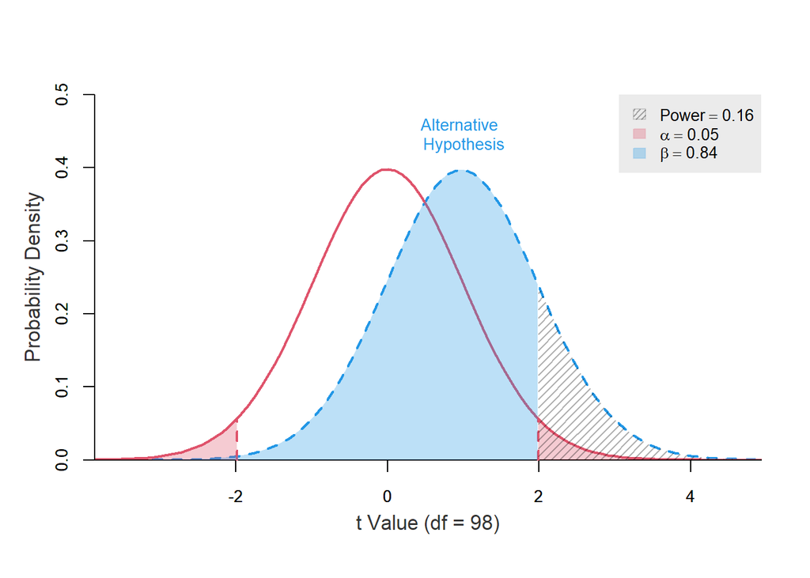

```r
## Calculate Statistical Power
pwrss.t.2means(mu1 = 30, mu2 = 28, sd1 = 12, sd2 = 8, kappa = 1,
               n2 = 50, alpha = 0.05,
               alternative = "not equal") %>% plot()
```

```
##  Difference between Two means
##  (Independent Samples t Test)
##  H0: mu1 = mu2
##  HA: mu1 != mu2
##  ------------------------------
##   Statistical power = 0.8
##   n1 = 410
##   n2 = 410
##  ------------------------------
##  Alternative = "not equal"
##  Degrees of freedom = 818
##  Non-centrality parameter = 2.808
##  Type I error rate = 0.05
##  Type II error rate = 0.2
```

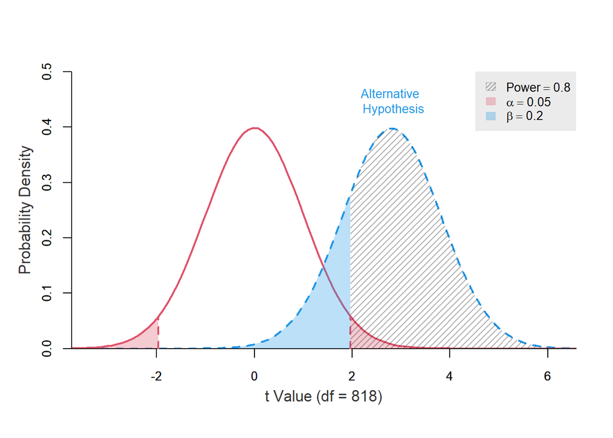

```r
## Calculate Minimum Required Sample Size
pwrss.t.2means(mu1 = 30, mu2 = 28, sd1 = 12, sd2 = 8, kappa = 1,
               power = .80, alpha = 0.05,
               alternative = "not equal") %>% plot()
```

## 3.4 Paired Samples t Test

```
##  Difference between Two means
##  (Paired Samples t Test)
##  H0: mu1 = mu2
##  HA: mu1 != mu2
##  ------------------------------
##   Statistical power = 0.8
##   n = 222
##  ------------------------------
##  Alternative = "not equal"
##  Degrees of freedom = 221
##  Non-centrality parameter = 2.816
##  Type I error rate = 0.05
##  Type II error rate = 0.2
```

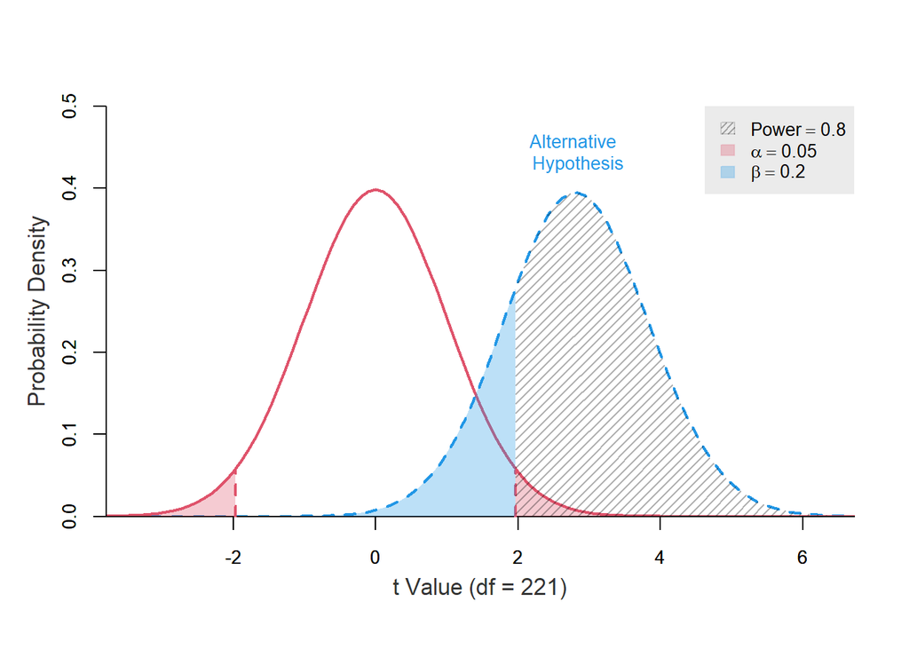

```r
pwrss.t.2means(mu1 = 30, mu2 = 28, sd1 = 12, sd2 = 8,
               paired = TRUE, paired.r = 0.50,
               power = .80, alpha = 0.05,
               alternative = "not equal") %>% plot()
```

## 3.5 Non-inferiority and Equivalence

```
##  Difference between Two means
##  (Independent Samples t Test)
##  H0: mu1 - mu2 <= margin
##  HA: mu1 - mu2 > margin
##  ------------------------------
##   Statistical power = 0.8
##   n1 = 144
##   n2 = 144
##  ------------------------------
##  Alternative = "non-inferior"
##  Degrees of freedom = 286
##  Non-centrality parameter = 2.496
##  Type I error rate = 0.05
##  Type II error rate = 0.2
```

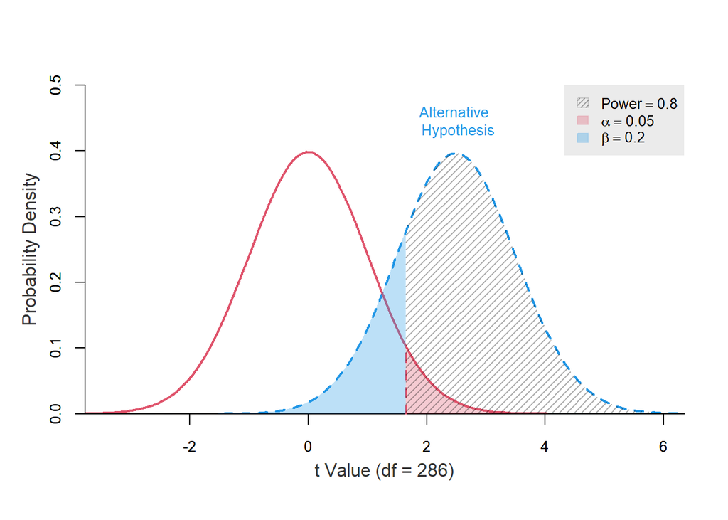

```r
## When higher values of an outcome is better the margin takes NEGATIVE values; whereas when lower values of the outcome is better margin takes POSITIVE values.
pwrss.t.2means(mu1 = 30, mu2 = 28, sd1 = 12, sd2 = 8,
               margin = -1, power = 0.80,
               alternative = "non-inferior")%>% plot()
```

```
##  Difference between Two means
##  (Independent Samples t Test)
##  H0: |mu1 - mu2| >= margin
##  HA: |mu1 - mu2| < margin
##  ------------------------------
##   Statistical power = 0.8
##   n1 = 1783
##   n2 = 1783
##  ------------------------------
##  Alternative = "equivalent"
##  Degrees of freedom = 3564
##  Non-centrality parameter = -2.928
##  Type I error rate = 0.05
##  Type II error rate = 0.2
```

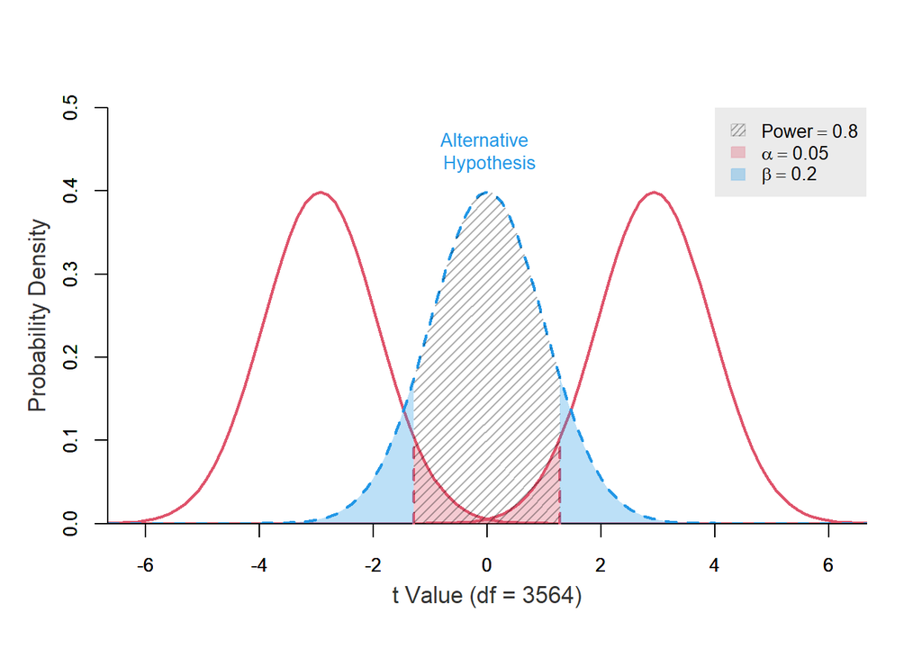

```r
## Specify the absolute value for the margin.
pwrss.t.2means(mu1 = 30, mu2 = 30, sd1 = 12, sd2 = 8,
               margin = 1, power = 0.80,
               alternative = "equivalent")%>% plot()
```

## 3.6 One-way, Two-way, and Three-way Analysis of Variance (ANOVA) or Analysis of Covariance (ANCOVA)

```
##  One-way Analysis of Variance (ANOVA)
##   H0: 'eta2' or 'f2' = 0
##   HA: 'eta2' or 'f2' > 0
##  --------------------------------------
##  Factor A: 2 levels
##  --------------------------------------
##  effect power n.total   ncp df1    df2
##       A   0.8      73 8.068   1 70.611
##  --------------------------------------
##  Type I error rate: 0.05
```

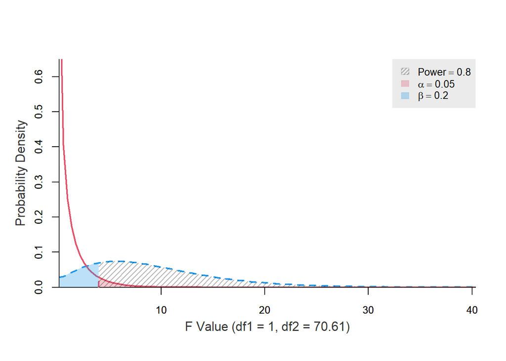

```r
# one-way ANOVA
pwrss.f.ancova(n.levels = 2, n.covariates = 0,
               power = .80, eta2 = 0.10)%>% plot()
```

```
##  One-way Analysis of Covariance (ANCOVA)
##   H0: 'eta2' or 'f2' = 0
##   HA: 'eta2' or 'f2' > 0
##  --------------------------------------
##  Factor A: 2 levels
##  --------------------------------------
##  effect power n.total   ncp df1    df2
##       A   0.8      93 8.021   1 89.244
##  --------------------------------------
##  Type I error rate: 0.05
```

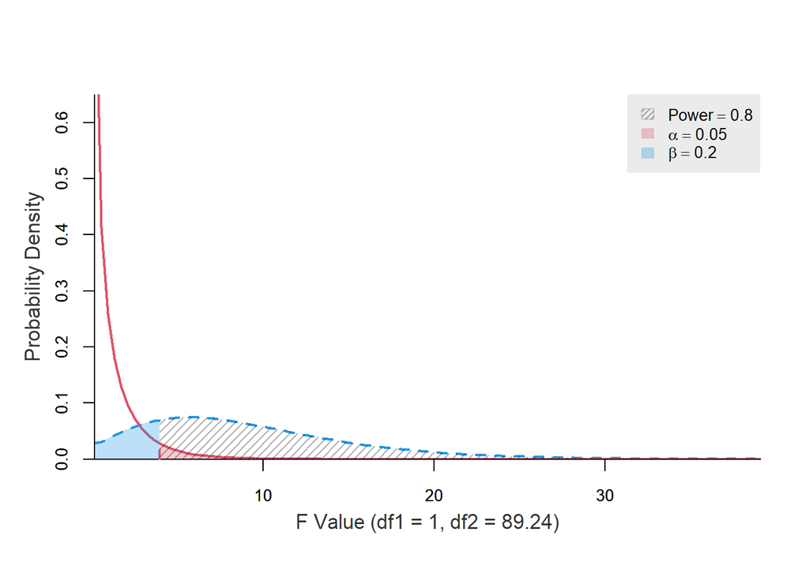

```r
# one-way ANCOVA
pwrss.f.ancova(n.levels = 2, n.covariates = 1,
               power = .80, eta2 = 0.08)%>% plot()
```

```r
# two-way ANOVA
pwrss.f.ancova(n.levels = c(2,3), n.covariates = 0,
               power = .80, eta2 = 0.10)
```

```
##  Two-way Analysis of Variance (ANOVA)
##   H0: 'eta2' or 'f2' = 0
##   HA: 'eta2' or 'f2' > 0
##  --------------------------------------
##  Factor A: 2 levels
##  Factor B: 3 levels
##  --------------------------------------
##  effect power n.total   ncp df1    df2
##       A   0.8      73 8.081   1 66.729
##       B   0.8      90 9.987   2 83.885
##   A x B   0.8      90 9.987   2 83.885
##  --------------------------------------
##  Type I error rate: 0.05
```

```r
# two-way ANCOVA
pwrss.f.ancova(n.levels = c(2,3), n.covariates = 1,
               power = .80, eta2 = 0.08)
```

```
##  Two-way Analysis of Covariance (ANCOVA)
##   H0: 'eta2' or 'f2' = 0
##   HA: 'eta2' or 'f2' > 0
##  --------------------------------------
##  Factor A: 2 levels
##  Factor B: 3 levels
##  --------------------------------------
##  effect power n.total   ncp df1     df2
##       A   0.8      93 8.029   1  85.337
##       B   0.8     114 9.910   2 106.962
##   A x B   0.8     114 9.910   2 106.962
##  --------------------------------------
##  Type I error rate: 0.05
```

```r
# three-way ANOVA
pwrss.f.ancova(n.levels = c(2,3,2), n.covariates = 0,
               power = .80, eta2 = 0.10)
```

```
##  Three-way Analysis of Variance (ANOVA)
##   H0: 'eta2' or 'f2' = 0
##   HA: 'eta2' or 'f2' > 0
##  --------------------------------------
##  Factor A: 2 levels
##  Factor B: 3 levels
##  Factor C: 2 levels
##  --------------------------------------
##     effect power n.total    ncp df1    df2
##          A   0.8      73  8.104   1 60.934
##          B   0.8      91 10.014   2 78.125
##          C   0.8      73  8.104   1 60.934
##      A x B   0.8      91 10.014   2 78.125
##      A x C   0.8      73  8.104   1 60.934
##      B x C   0.8      91 10.014   2 78.125
##  A x B x C   0.8      91 10.014   2 78.125
##  --------------------------------------
##  Type I error rate: 0.05
```

```r
# three-way ANCOVA
pwrss.f.ancova(n.levels = c(2,3,2), n.covariates = 1,
               power = .80, eta2 = 0.08)
```

```
##  Three-way Analysis of Covariance (ANCOVA)
##   H0: 'eta2' or 'f2' = 0
##   HA: 'eta2' or 'f2' > 0
##  --------------------------------------
##  Factor A: 2 levels
##  Factor B: 3 levels
##  Factor C: 2 levels
##  --------------------------------------
##     effect power n.total   ncp df1     df2
##          A   0.8      93 8.043   1  79.493
##          B   0.8     115 9.926   2 101.147
##          C   0.8      93 8.043   1  79.493
##      A x B   0.8     115 9.926   2 101.147
##      A x C   0.8      93 8.043   1  79.493
##      B x C   0.8     115 9.926   2 101.147
##  A x B x C   0.8     115 9.926   2 101.147
##  --------------------------------------
##  Type I error rate: 0.05
```